# Part_II_Slideshow slides

## Part II : Presentation of No_show Medical Appointment in Brazil

## Chukwuma Anthony Nwachukwu

## Investigation Overview

In this investigation, I'm most interested in figuring out what features affected no_show the reason for the effect

Starting from individual distributions of all the feature, I explored there relationships with no_show and made plot on how likely a patient will show up or not based on those features.

## Dataset Overview

> This dataset contains the medical appointment dataset of over 110,527 entries obtained from hosptitals in Brazil, it shows whether a patient shows for a appointment and several other features that might affect that, I feature engineered a few new columns to suit my analysis.

The original dataset was obtained from [kaggle](https://www.kaggle.com/datasets/joniarroba/noshowappointments/download?datasetVersionNumber=5) whereas the one used here was a cleaned version of it.

> We will be finding why most patients do not show up to their medical appointment

|  | gender | scheduled_date | appointment_date | age | hospital_locations | scholarship | hypertension | diabetes | alcoholism | handicapped | sms_received | no_show | appointment_day | days_before_visit | day_range |
| --- | --- | --- | --- | --- | --- | --- | --- | --- | --- | --- | --- | --- | --- | --- | --- |
| 0 | F | 2016-04-29 | 2016-04-29 | 62 | jardim da penha | False | True | False | False | 0 | False | No | Friday | 0 | Same day |
| 1 | M | 2016-04-29 | 2016-04-29 | 56 | jardim da penha | False | False | False | False | 0 | False | No | Friday | 0 | Same day |
| 2 | F | 2016-04-29 | 2016-04-29 | 62 | mata da praia | False | False | False | False | 0 | False | No | Friday | 0 | Same day |
| 3 | F | 2016-04-29 | 2016-04-29 | 8 | pontal de camburi | False | False | False | False | 0 | False | No | Friday | 0 | Same day |
| 4 | F | 2016-04-29 | 2016-04-29 | 56 | jardim da penha | False | True | True | False | 0 | False | No | Friday | 0 | Same day |

### Column Description:

- **gender** - Male or Female . Female is the greater proportion, woman takes way more care of they health in comparison to man.
- **appointment_date** - The day of the actuall appointment, when they have to visit the doctor.
- **schedule_date** - The day someone called or registered the appointment, this is before appointment of course.
- **Age** - How old is the patient.
- **hospital_locations** - Where the appointment takes place.
- **Scholarship** - True of False if they have one or not
- **hypertension** - True or False if they have one or not
- **diabetes** - True or False if they have one or not
- **Alcoholism** - True or False if they have one or not
- **Handcap** - - 1 or more illness with 0= none and 4 meaning max
- **SMS_received** - True or False if they have one or not
- **No-Show** - True or False, if they have one or not.
- **appointment_day**- day of the week the appointment
- **days_before_visit** - The day difference between schedule and appointment day.
- **day_range** - A category assigned to days_before_visit based on certain ranges.
  - Late - any days_before_visit below 0
  - Same_day - - any days_before_visit = 0
  - Short - any days_before_visit 1-3
  - Week - any days_before_visit 4-7
  - Fortnight - any days_before_visit 7-14
  - Monthly - any days_before_visit 14-30
  - Quarterly - any days_before_visit 30-90
  - Semester - any days_before_visit > 90

### No_Show Distribution

**We can notice that on the no_show feature which is the main focus on this dataset shows that patients do show up for medical appointments far more than they don't**

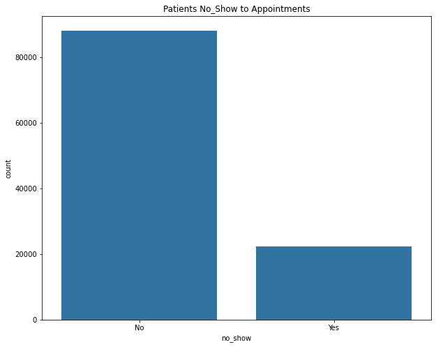

### Age Distribution

**This shows the the distribution of the age feature with *mean age = 37.088874*, *min age = -1*, *25th percentile = 18*, *50th percentile = 37*, *75th percentile = 55* and *max age = 115*, also shows that value_counts of all ages on the dataset with *0* have the maximum count and *-1* having the least**

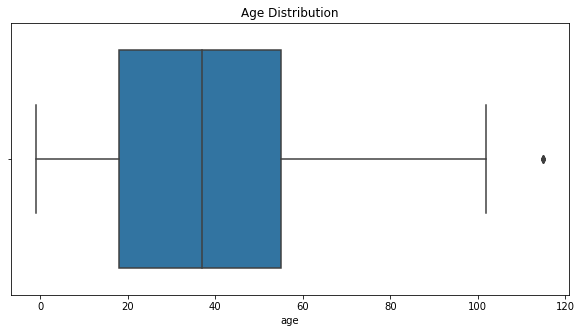

[figure not shown]

### Hospital_Locations Distribution

**It is noticed that neighbourhood *jardim camburi* have the most patients going there and *parque industrial* has just one patient on the dataset**

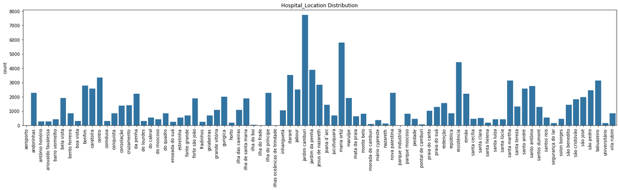

### Gende Distribution

**Patients that are females have a higher count than males on the dataset**

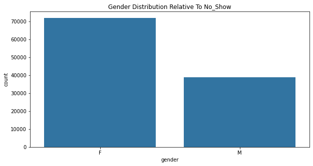

### Scholarship Distribution

**Patients that don't have scholarships have a much larger value count compare to those that do**

[figure not shown]

### Sms_Recieved Distribution

**Patients that didn't recieve an sms have a much larger value count compare to those that did**

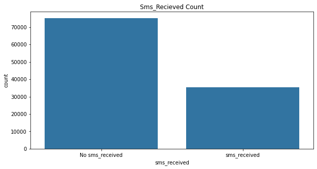

### Handicapped Distribution

**Patients are not Handicapped *0* have a bigger value count compare to those that do ranging from *1-4* with 4 being the most handicapped category**

[figure not shown]

### Diabetes Distribution

**Patients are not Diabetic have a bigger value count compare to those that do**

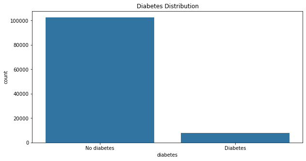

### Alcoholism

**Patients that don't have Alcoholism have a bigger value count compare to those that do**

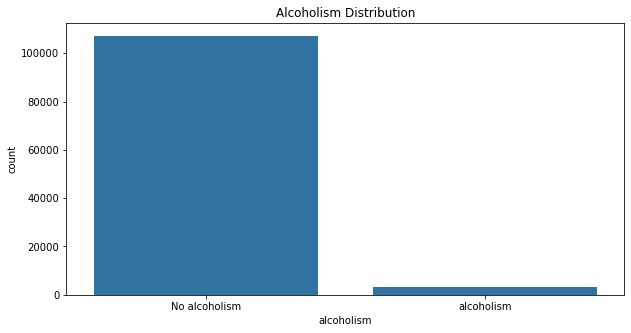

### Hypertension Distribution

**Patients that don't have Hypertension have a higher count than patients that do have the Hypertension illness**

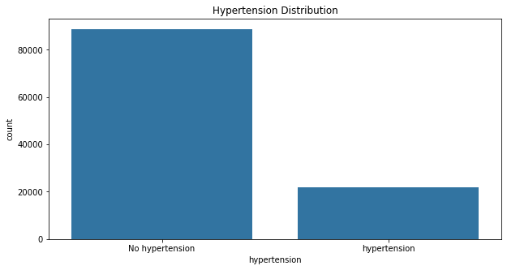

### Appointment_Day Distribution

**This also proves that appointment_days on *Wednesday* and *Tuesday* have the more counts whereas *Saturday* has the least value count**

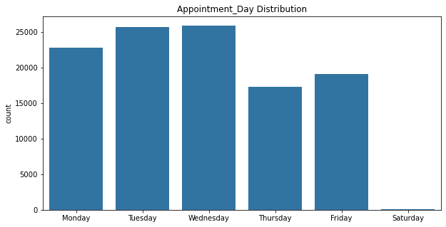

### Day_range Distribution

**It can on observe that *Same_day* has more counts compared to *Semester* and *Late***

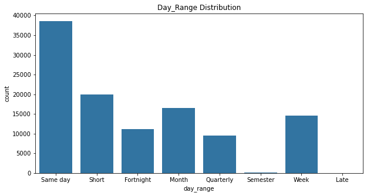

## Exploration with no_show shows the different percentage of no_show per feature

**No_show (independent variable)**

**We notice a warping 79.8% of patients show up for appointments while only 20.2% of them don't, then attempt to see how much of other features affect no_show**

### Age

**One can noticed that patients of all ages have a high tendecy to show up for medical appointment with the most likely being age *-1* (antenatal treatment for a baby) and the least likely to show up for appointment is older patient with age *115***

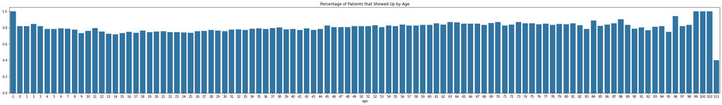

### **Considering Hospital location**

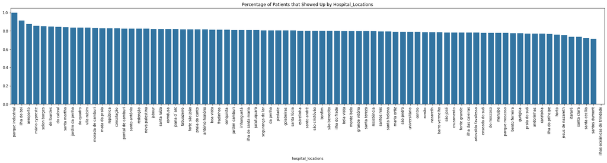

### Gender

**Patients that are males have a slightlu higher tendency to show up to medical appointments with 0.8 or 80% than females with 0.797 or 79.7%**

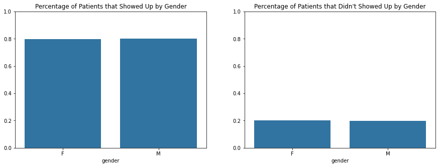

### Scholarship_Ratio of patient's appointments to no_show

**We notice that patients show up for appointment regardless on if they have scholarships or not whith more likely to fall on the no_scholarship category**

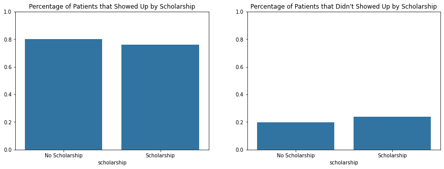

### Sms_Recieved_Ratio of patient's appointments to no_show

**We see that whether or not a patient recieves an sms doesn't have much effect if they show for an appointment because they show up eitherways but those that don't recieve an sms tend to show up more**

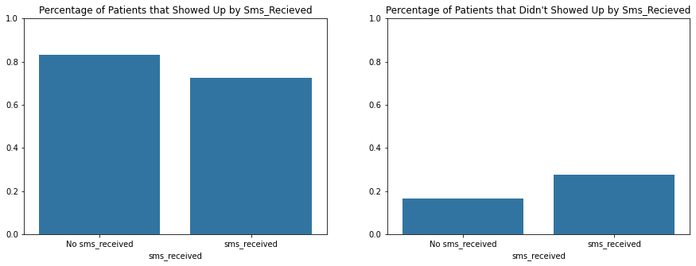

### Handicapped_Ratio of patient's appointments to no_show

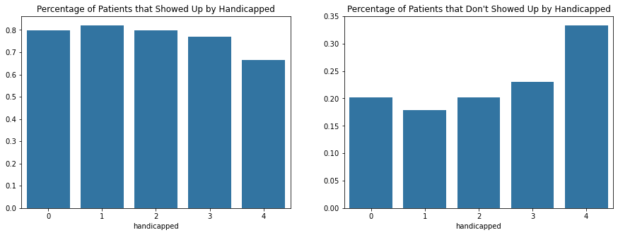

### Diabetes_Ratio of patient's appointments to no_show

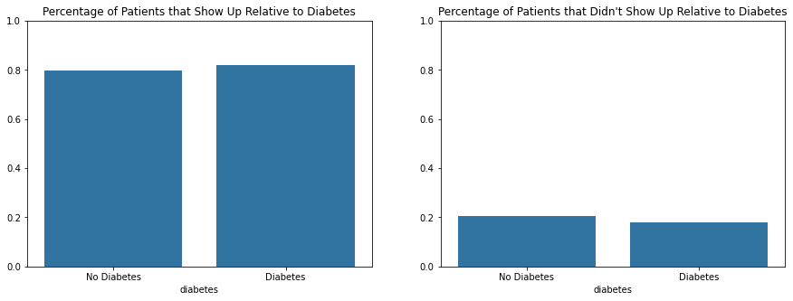

### Alcoholism_Ratio of patient's appointments to no_show

**Patients do show up for appointments more than they don't whether they are Alcoholics or not since their tendency to show up both lies in the range *0.7980-0.7985***

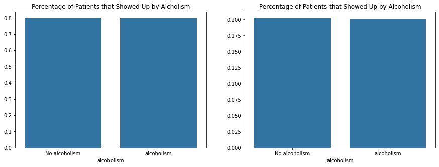